# PHIẾU CẮT & THEO DÕI GIAO NHẬN - POLOMIMIN

PHIẾU CẮT & THEO DÕI GIAO NHẬN - POLOMIMIN

NGÀY LẬP PHIẾU

18 / 10 / 2026

MÃ PHIẾU CẮT

GC-20260319-001

Trạng thái: CHỜ KIỂM TRA

CÔNG TY TNHH DỆT MAY GIÀU SANG | MST: 0318507560 | Hotline: 0774480916 | 12/39 Xuân Thới Thượng 58C, Hóc Môn, TP.HCM

1. THÔNG TIN CHUNG & CHỈ TIÊU KIỂM ĐẾM

HÌNH ẢNH SẢN PHẨM

Mã hàng / Tên sản phẩm

M01 - BỘ TRÒN TRƠN

SL phiếu:

320 cái

[figure not shown]

Tổng ký chuẩn (kg)

520 kg

Tổng ký thực tế (kg)

kg

Tổng màu & Tỉ lệ size

4 màu | 1-1-1-1

SL 1 màu:

80 cái (130 kg)

2. CHIA THEO MÀU (THEO TỶ LỆ SIZE & KG CHUẨN)

*Ghi chú: Đổi tên màu ở dòng tiêu đề để bảng đồng bộ xuống Mục 3; nhập tỉ lệ từng size (cột Tỉ lệ) và số kg cân thực tế từng màu.*

STT

SIZE / CHỈ TIÊU

TỈ LỆ

ĐEN

TRẮNG

XANH ĐEN

XÁM

TỔNG

GHI CHÚ SIZE

1

Size L

1

20

20

20

20

80

2

Size XL

1

20

20

20

20

80

3

Size XXL

1

20

20

20

20

80

4

Size 3XL

1

20

20

20

20

80

TỔNG SỐ LƯỢNG (CÁI)

4

80

80

80

80

320

Số kg chuẩn (kg)

Chuẩn

130

130

130

130

520

Theo định mức

Số kg thực tế (kg)

Cân TT

3. THEO DÕI CÁC KHÂU & SẢN LƯỢNG (KIỂM ĐẾM THỰC TẾ TỪNG MÀU)

STT

KHÂU / CÔNG ĐOẠN

ĐEN

TRẮNG

XANH ĐEN

XÁM

TỔNG (CÁI)

KÝ TÊN

1

Giao hàng

2

Khuy nút

3

Lỗi (Khuy nút)

4

Ủi

5

Lỗi (Ủi)

6

Đóng gói

7

Lỗi (Đóng gói)

8

Nhập kho

Chênh lệch từng màu (Kho - Giao)

Khâu ủi + Giao hàng xác nhận: ☐ Đủ theo kg & số lượng ☐ Thiếu theo kg / số lượng

Ký xác nhận gia công:

4. XÁC NHẬN & HÀNG SỬA

Tổng số lượng hàng lỗi:

cái

Loại lỗi chính:

Vải, chỉ, size, màu...

Số lượng sửa (cái):

cái

Trạng thái sửa:

☐ Đã sửa ☐ Chưa sửa

* Ghi chú thêm:

Đơn vị gia công: In/Thêu: Xưởng in anh Trung Nha Trang | May áo: Xưởng may tròn anh Trai | May quần: Xưởng may quần chị Dung

5. KẾT LUẬN & ĐỐI CHIẾU THIẾU HỤT (NHẬP KHO - GIAO HÀNG)

Tổng nhập kho thành phẩm:

cái

Chênh lệch (Kho - Giao):

cái

☐ Đủ ☐ Thiếu

*Công thức đối soát: Chênh lệch = Tổng nhập kho - Giao hàng | Lệch chưa rõ = (Giao hàng - Nhập kho) - (Tổng lỗi - SL đã sửa)*

NGƯỜI LẬP / GIAO HÀNG

TỔ KIỂM HÀNG (KHUY NÚT - ỦI - ĐÓNG GÓI)

THỦ KHO / QUẢN LÝ

(Ký, ghi rõ họ tên)

(Ký, ghi rõ họ tên)

(Ký, ghi rõ họ tên)

PHIẾU CẮT & THEO DÕI GIAO NHẬN - POLOMIMIN

NGÀY LẬP PHIẾU

18 / 10 / 2026

MÃ PHIẾU CẮT

GC-20260319-001

Trạng thái: CHỜ KIỂM TRA

CÔNG TY TNHH DỆT MAY GIÀU SANG | MST: 0318507560 | Hotline: 0774480916 | 12/39 Xuân Thới Thượng 58C, Hóc Môn, TP.HCM

1. THÔNG TIN CHUNG & CHỈ TIÊU KIỂM ĐẾM

HÌNH ẢNH SẢN PHẨM

Mã hàng / Tên sản phẩm

M02 - BỘ TRÒN LÉ ĐÔ M02

SL phiếu:

288 cái

[figure not shown]

Tổng ký chuẩn (kg)

520 kg

Tổng ký thực tế (kg)

kg

Tổng màu & Tỉ lệ size

4 màu | 1-1-1-1

SL 1 màu:

72 cái (130 kg)

2. CHIA THEO MÀU (THEO TỶ LỆ SIZE & KG CHUẨN)

*Ghi chú: Đổi tên màu ở dòng tiêu đề để bảng đồng bộ xuống Mục 3; nhập tỉ lệ từng size (cột Tỉ lệ) và số kg cân thực tế từng màu.*

STT

SIZE / CHỈ TIÊU

TỈ LỆ

ĐEN

DA

TRẮNG

XAM ĐẬM

TỔNG

GHI CHÚ SIZE

1

Size L

1

18

18

18

18

72

2

Size XL

1

18

18

18

18

72

3

Size XXL

1

18

18

18

18

72

4

Size 3XL

1

18

18

18

18

72

TỔNG SỐ LƯỢNG (CÁI)

4

72

72

72

72

288

Số kg chuẩn (kg)

Chuẩn

130

130

130

130

520

Theo định mức

Số kg thực tế (kg)

Cân TT

3. THEO DÕI CÁC KHÂU & SẢN LƯỢNG (KIỂM ĐẾM THỰC TẾ TỪNG MÀU)

STT

KHÂU / CÔNG ĐOẠN

ĐEN

DA

TRẮNG

XAM ĐẬM

TỔNG (CÁI)

KÝ TÊN

1

Giao hàng

2

Khuy nút

3

Lỗi (Khuy nút)

4

Ủi

5

Lỗi (Ủi)

6

Đóng gói

7

Lỗi (Đóng gói)

8

Nhập kho

Chênh lệch từng màu (Kho - Giao)

Khâu ủi + Giao hàng xác nhận: ☐ Đủ theo kg & số lượng ☐ Thiếu theo kg / số lượng

Ký xác nhận gia công:

4. XÁC NHẬN & HÀNG SỬA

Tổng số lượng hàng lỗi:

cái

Loại lỗi chính:

Vải, chỉ, size, màu...

Số lượng sửa (cái):

cái

Trạng thái sửa:

☐ Đã sửa ☐ Chưa sửa

* Ghi chú thêm:

Đơn vị gia công: In/Thêu: Xưởng in anh Trung Nha Trang | May áo: Xưởng may tròn anh Trai | May quần: Xưởng may quần chị Dung

5. KẾT LUẬN & ĐỐI CHIẾU THIẾU HỤT (NHẬP KHO - GIAO HÀNG)

Tổng nhập kho thành phẩm:

cái

Chênh lệch (Kho - Giao):

cái

☐ Đủ ☐ Thiếu

*Công thức đối soát: Chênh lệch = Tổng nhập kho - Giao hàng | Lệch chưa rõ = (Giao hàng - Nhập kho) - (Tổng lỗi - SL đã sửa)*

NGƯỜI LẬP / GIAO HÀNG

TỔ KIỂM HÀNG (KHUY NÚT - ỦI - ĐÓNG GÓI)

THỦ KHO / QUẢN LÝ

(Ký, ghi rõ họ tên)

(Ký, ghi rõ họ tên)

(Ký, ghi rõ họ tên)

PHIẾU CẮT & THEO DÕI GIAO NHẬN - POLOMIMIN

NGÀY LẬP PHIẾU

18 / 10 / 2026

MÃ PHIẾU CẮT

GC-20260319-001

Trạng thái: CHỜ KIỂM TRA

CÔNG TY TNHH DỆT MAY GIÀU SANG | MST: 0318507560 | Hotline: 0774480916 | 12/39 Xuân Thới Thượng 58C, Hóc Môn, TP.HCM

1. THÔNG TIN CHUNG & CHỈ TIÊU KIỂM ĐẾM

HÌNH ẢNH SẢN PHẨM

Mã hàng / Tên sản phẩm

M03 - BỘ TRÒN TRƠN CHẠY DÂY VAI M03

SL phiếu:

288 cái

[figure not shown]

Tổng ký chuẩn (kg)

520 kg

Tổng ký thực tế (kg)

kg

Tổng màu & Tỉ lệ size

4 màu | 1-1-1-1

SL 1 màu:

72 cái (130 kg)

2. CHIA THEO MÀU (THEO TỶ LỆ SIZE & KG CHUẨN)

*Ghi chú: Đổi tên màu ở dòng tiêu đề để bảng đồng bộ xuống Mục 3; nhập tỉ lệ từng size (cột Tỉ lệ) và số kg cân thực tế từng màu.*

STT

SIZE / CHỈ TIÊU

TỈ LỆ

ĐEN

DA

TRẮNG

XAM ĐẬM

TỔNG

GHI CHÚ SIZE

1

Size L

1

18

18

18

18

72

2

Size XL

1

18

18

18

18

72

3

Size XXL

1

18

18

18

18

72

4

Size 3XL

1

18

18

18

18

72

TỔNG SỐ LƯỢNG (CÁI)

4

72

72

72

72

288

Số kg chuẩn (kg)

Chuẩn

130

130

130

130

520

Theo định mức

Số kg thực tế (kg)

Cân TT

3. THEO DÕI CÁC KHÂU & SẢN LƯỢNG (KIỂM ĐẾM THỰC TẾ TỪNG MÀU)

STT

KHÂU / CÔNG ĐOẠN

ĐEN

DA

TRẮNG

XAM ĐẬM

TỔNG (CÁI)

KÝ TÊN

1

Giao hàng

2

Khuy nút

3

Lỗi (Khuy nút)

4

Ủi

5

Lỗi (Ủi)

6

Đóng gói

7

Lỗi (Đóng gói)

8

Nhập kho

Chênh lệch từng màu (Kho - Giao)

Khâu ủi + Giao hàng xác nhận: ☐ Đủ theo kg & số lượng ☐ Thiếu theo kg / số lượng

Ký xác nhận gia công:

4. XÁC NHẬN & HÀNG SỬA

Tổng số lượng hàng lỗi:

cái

Loại lỗi chính:

Vải, chỉ, size, màu...

Số lượng sửa (cái):

cái

Trạng thái sửa:

☐ Đã sửa ☐ Chưa sửa

* Ghi chú thêm:

Đơn vị gia công: In/Thêu: Xưởng thêu anh Vui | May áo: Xưởng may tròn anh Trai | May quần: Xưởng may quần chị Dung

5. KẾT LUẬN & ĐỐI CHIẾU THIẾU HỤT (NHẬP KHO - GIAO HÀNG)

Tổng nhập kho thành phẩm:

cái

Chênh lệch (Kho - Giao):

cái

☐ Đủ ☐ Thiếu

*Công thức đối soát: Chênh lệch = Tổng nhập kho - Giao hàng | Lệch chưa rõ = (Giao hàng - Nhập kho) - (Tổng lỗi - SL đã sửa)*

NGƯỜI LẬP / GIAO HÀNG

TỔ KIỂM HÀNG (KHUY NÚT - ỦI - ĐÓNG GÓI)

THỦ KHO / QUẢN LÝ

(Ký, ghi rõ họ tên)

(Ký, ghi rõ họ tên)

(Ký, ghi rõ họ tên)

PHIẾU CẮT & THEO DÕI GIAO NHẬN - POLOMIMIN

NGÀY LẬP PHIẾU

18 / 10 / 2026

MÃ PHIẾU CẮT

GC-20260319-001

Trạng thái: CHỜ KIỂM TRA

CÔNG TY TNHH DỆT MAY GIÀU SANG | MST: 0318507560 | Hotline: 0774480916 | 12/39 Xuân Thới Thượng 58C, Hóc Môn, TP.HCM

1. THÔNG TIN CHUNG & CHỈ TIÊU KIỂM ĐẾM

HÌNH ẢNH SẢN PHẨM

Mã hàng / Tên sản phẩm

M04 - BỘ TRÒN PHỐI ĐÔ M04

SL phiếu:

384 cái

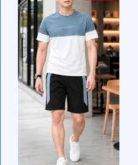

Tổng ký chuẩn (kg)

520 kg

Tổng ký thực tế (kg)

kg

Tổng màu & Tỉ lệ size

4 màu | 1-1-1-1

SL 1 màu:

96 cái (130 kg)

2. CHIA THEO MÀU (THEO TỶ LỆ SIZE & KG CHUẨN)

*Ghi chú: Đổi tên màu ở dòng tiêu đề để bảng đồng bộ xuống Mục 3; nhập tỉ lệ từng size (cột Tỉ lệ) và số kg cân thực tế từng màu.*

STT

SIZE / CHỈ TIÊU

TỈ LỆ

ĐEN CM-FOI DA

DA- FOI ĐEN CM

TRẮNG- FOI XANH ĐÁ

XANH ĐÁ 08- FOI TRẮNG

TỔNG

GHI CHÚ SIZE

1

Size L

1

24

24

24

24

96

2

Size XL

1

24

24

24

24

96

3

Size XXL

1

24

24

24

24

96

4

Size 3XL

1

24

24

24

24

96

TỔNG SỐ LƯỢNG (CÁI)

4

96

96

96

96

384

Số kg chuẩn (kg)

Chuẩn

130

130

130

130

520

Theo định mức

Số kg thực tế (kg)

Cân TT

3. THEO DÕI CÁC KHÂU & SẢN LƯỢNG (KIỂM ĐẾM THỰC TẾ TỪNG MÀU)

STT

KHÂU / CÔNG ĐOẠN

ĐEN CM-FOI DA

DA- FOI ĐEN CM

TRẮNG- FOI XANH ĐÁ

XANH ĐÁ 08- FOI TRẮNG

TỔNG (CÁI)

KÝ TÊN

1

Giao hàng

2

Khuy nút

3

Lỗi (Khuy nút)

4

Ủi

5

Lỗi (Ủi)

6

Đóng gói

7

Lỗi (Đóng gói)

8

Nhập kho

Chênh lệch từng màu (Kho - Giao)

Khâu ủi + Giao hàng xác nhận: ☐ Đủ theo kg & số lượng ☐ Thiếu theo kg / số lượng

Ký xác nhận gia công:

4. XÁC NHẬN & HÀNG SỬA

Tổng số lượng hàng lỗi:

cái

Loại lỗi chính:

Vải, chỉ, size, màu...

Số lượng sửa (cái):

cái

Trạng thái sửa:

☐ Đã sửa ☐ Chưa sửa

* Ghi chú thêm:

Đơn vị gia công: In/Thêu: Xưởng thêu anh Vui | May áo: Xưởng may tròn anh Chiến | May quần: Xưởng may quần chị Hương

5. KẾT LUẬN & ĐỐI CHIẾU THIẾU HỤT (NHẬP KHO - GIAO HÀNG)

Tổng nhập kho thành phẩm:

cái

Chênh lệch (Kho - Giao):

cái

☐ Đủ ☐ Thiếu

*Công thức đối soát: Chênh lệch = Tổng nhập kho - Giao hàng | Lệch chưa rõ = (Giao hàng - Nhập kho) - (Tổng lỗi - SL đã sửa)*

NGƯỜI LẬP / GIAO HÀNG

TỔ KIỂM HÀNG (KHUY NÚT - ỦI - ĐÓNG GÓI)

THỦ KHO / QUẢN LÝ

(Ký, ghi rõ họ tên)

(Ký, ghi rõ họ tên)

(Ký, ghi rõ họ tên)

PHIẾU CẮT & THEO DÕI GIAO NHẬN - POLOMIMIN

NGÀY LẬP PHIẾU

18 / 10 / 2026

MÃ PHIẾU CẮT

GC-20260319-001

Trạng thái: CHỜ KIỂM TRA

CÔNG TY TNHH DỆT MAY GIÀU SANG | MST: 0318507560 | Hotline: 0774480916 | 12/39 Xuân Thới Thượng 58C, Hóc Môn, TP.HCM

1. THÔNG TIN CHUNG & CHỈ TIÊU KIỂM ĐẾM

HÌNH ẢNH SẢN PHẨM

Mã hàng / Tên sản phẩm

M05 - BỘ TRÒN PHỐI SƯỜN M05

SL phiếu:

384 cái

[figure not shown]

Tổng ký chuẩn (kg)

520 kg

Tổng ký thực tế (kg)

kg

Tổng màu & Tỉ lệ size

4 màu | 1-1-1-1

SL 1 màu:

96 cái (130 kg)

2. CHIA THEO MÀU (THEO TỶ LỆ SIZE & KG CHUẨN)

*Ghi chú: Đổi tên màu ở dòng tiêu đề để bảng đồng bộ xuống Mục 3; nhập tỉ lệ từng size (cột Tỉ lệ) và số kg cân thực tế từng màu.*

STT

SIZE / CHỈ TIÊU

TỈ LỆ

ĐEN CM-FOI DA

DA- FOI ĐEN CM

TRẮNG- FOI XANH ĐÁ

XANH ĐÁ 08- FOI TRẮNG

TỔNG

GHI CHÚ SIZE

1

Size L

1

24

24

24

24

96

2

Size XL

1

24

24

24

24

96

3

Size XXL

1

24

24

24

24

96

4

Size 3XL

1

24

24

24

24

96

TỔNG SỐ LƯỢNG (CÁI)

4

96

96

96

96

384

Số kg chuẩn (kg)

Chuẩn

130

130

130

130

520

Theo định mức

Số kg thực tế (kg)

Cân TT

3. THEO DÕI CÁC KHÂU & SẢN LƯỢNG (KIỂM ĐẾM THỰC TẾ TỪNG MÀU)

STT

KHÂU / CÔNG ĐOẠN

ĐEN CM-FOI DA

DA- FOI ĐEN CM

TRẮNG- FOI XANH ĐÁ

XANH ĐÁ 08- FOI TRẮNG

TỔNG (CÁI)

KÝ TÊN

1

Giao hàng

2

Khuy nút

3

Lỗi (Khuy nút)

4

Ủi

5

Lỗi (Ủi)

6

Đóng gói

7

Lỗi (Đóng gói)

8

Nhập kho

Chênh lệch từng màu (Kho - Giao)

Khâu ủi + Giao hàng xác nhận: ☐ Đủ theo kg & số lượng ☐ Thiếu theo kg / số lượng

Ký xác nhận gia công:

4. XÁC NHẬN & HÀNG SỬA

Tổng số lượng hàng lỗi:

cái

Loại lỗi chính:

Vải, chỉ, size, màu...

Số lượng sửa (cái):

cái

Trạng thái sửa:

☐ Đã sửa ☐ Chưa sửa

* Ghi chú thêm:

Đơn vị gia công: In/Thêu: Xưởng thêu chị Hạnh | May áo: Xưởng may tròn anh Chiến | May quần: Xưởng may quần chị Hương

5. KẾT LUẬN & ĐỐI CHIẾU THIẾU HỤT (NHẬP KHO - GIAO HÀNG)

Tổng nhập kho thành phẩm:

cái

Chênh lệch (Kho - Giao):

cái

☐ Đủ ☐ Thiếu

*Công thức đối soát: Chênh lệch = Tổng nhập kho - Giao hàng | Lệch chưa rõ = (Giao hàng - Nhập kho) - (Tổng lỗi - SL đã sửa)*

NGƯỜI LẬP / GIAO HÀNG

TỔ KIỂM HÀNG (KHUY NÚT - ỦI - ĐÓNG GÓI)

THỦ KHO / QUẢN LÝ

(Ký, ghi rõ họ tên)

(Ký, ghi rõ họ tên)

(Ký, ghi rõ họ tên)

PHIẾU CẮT & THEO DÕI GIAO NHẬN - POLOMIMIN

NGÀY LẬP PHIẾU

18 / 10 / 2026

MÃ PHIẾU CẮT

GC-20260319-001

Trạng thái: CHỜ KIỂM TRA

CÔNG TY TNHH DỆT MAY GIÀU SANG | MST: 0318507560 | Hotline: 0774480916 | 12/39 Xuân Thới Thượng 58C, Hóc Môn, TP.HCM

1. THÔNG TIN CHUNG & CHỈ TIÊU KIỂM ĐẾM

HÌNH ẢNH SẢN PHẨM

Mã hàng / Tên sản phẩm

M06 - BỘ TRÒN PHỐI TAY M06

SL phiếu:

320 cái

[figure not shown]

Tổng ký chuẩn (kg)

520 kg

Tổng ký thực tế (kg)

kg

Tổng màu & Tỉ lệ size

4 màu | 1-1-1-1

SL 1 màu:

80 cái (130 kg)

2. CHIA THEO MÀU (THEO TỶ LỆ SIZE & KG CHUẨN)

*Ghi chú: Đổi tên màu ở dòng tiêu đề để bảng đồng bộ xuống Mục 3; nhập tỉ lệ từng size (cột Tỉ lệ) và số kg cân thực tế từng màu.*

STT

SIZE / CHỈ TIÊU

TỈ LỆ

ĐEN PHỐI XÁM NHẠT

RÊU PHỐI TRẮNG

TRẮNG PHỐI RÊU

XÁM NHẠT PHỐI ĐEN

TỔNG

GHI CHÚ SIZE

1

Size L

1

20

20

20

20

80

2

Size XL

1

20

20

20

20

80

3

Size XXL

1

20

20

20

20

80

4

Size 3XL

1

20

20

20

20

80

TỔNG SỐ LƯỢNG (CÁI)

4

80

80

80

80

320

Số kg chuẩn (kg)

Chuẩn

130

130

130

130

520

Theo định mức

Số kg thực tế (kg)

Cân TT

3. THEO DÕI CÁC KHÂU & SẢN LƯỢNG (KIỂM ĐẾM THỰC TẾ TỪNG MÀU)

STT

KHÂU / CÔNG ĐOẠN

ĐEN PHỐI XÁM NHẠT

RÊU PHỐI TRẮNG

TRẮNG PHỐI RÊU

XÁM NHẠT PHỐI ĐEN

TỔNG (CÁI)

KÝ TÊN

1

Giao hàng

2

Khuy nút

3

Lỗi (Khuy nút)

4

Ủi

5

Lỗi (Ủi)

6

Đóng gói

7

Lỗi (Đóng gói)

8

Nhập kho

Chênh lệch từng màu (Kho - Giao)

Khâu ủi + Giao hàng xác nhận: ☐ Đủ theo kg & số lượng ☐ Thiếu theo kg / số lượng

Ký xác nhận gia công:

4. XÁC NHẬN & HÀNG SỬA

Tổng số lượng hàng lỗi:

cái

Loại lỗi chính:

Vải, chỉ, size, màu...

Số lượng sửa (cái):

cái

Trạng thái sửa:

☐ Đã sửa ☐ Chưa sửa

* Ghi chú thêm:

Đơn vị gia công: In/Thêu: Xưởng in anh Trung Nha Trang | May áo: Xưởng may tròn anh Trai | May quần: Xưởng may quần chị Dung

5. KẾT LUẬN & ĐỐI CHIẾU THIẾU HỤT (NHẬP KHO - GIAO HÀNG)

Tổng nhập kho thành phẩm:

cái

Chênh lệch (Kho - Giao):

cái

☐ Đủ ☐ Thiếu

*Công thức đối soát: Chênh lệch = Tổng nhập kho - Giao hàng | Lệch chưa rõ = (Giao hàng - Nhập kho) - (Tổng lỗi - SL đã sửa)*

NGƯỜI LẬP / GIAO HÀNG

TỔ KIỂM HÀNG (KHUY NÚT - ỦI - ĐÓNG GÓI)

THỦ KHO / QUẢN LÝ

(Ký, ghi rõ họ tên)

(Ký, ghi rõ họ tên)

(Ký, ghi rõ họ tên)

PHIẾU CẮT & THEO DÕI GIAO NHẬN - POLOMIMIN

NGÀY LẬP PHIẾU

18 / 10 / 2026

MÃ PHIẾU CẮT

GC-20260319-001

Trạng thái: CHỜ KIỂM TRA

CÔNG TY TNHH DỆT MAY GIÀU SANG | MST: 0318507560 | Hotline: 0774480916 | 12/39 Xuân Thới Thượng 58C, Hóc Môn, TP.HCM

1. THÔNG TIN CHUNG & CHỈ TIÊU KIỂM ĐẾM

HÌNH ẢNH SẢN PHẨM

Mã hàng / Tên sản phẩm

M07 - BỘ TRỤ PHỐI TAY M07

SL phiếu:

320 cái

[figure not shown]

Tổng ký chuẩn (kg)

520 kg

Tổng ký thực tế (kg)

kg

Tổng màu & Tỉ lệ size

4 màu | 1-1-1-1

SL 1 màu:

80 cái (130 kg)

2. CHIA THEO MÀU (THEO TỶ LỆ SIZE & KG CHUẨN)

*Ghi chú: Đổi tên màu ở dòng tiêu đề để bảng đồng bộ xuống Mục 3; nhập tỉ lệ từng size (cột Tỉ lệ) và số kg cân thực tế từng màu.*

STT

SIZE / CHỈ TIÊU

TỈ LỆ

ĐEN PHỐI XÁM NHẠT

RÊU PHỐI TRẮNG

TRẮNG PHỐI RÊU

XÁM NHẠT PHỐI ĐEN

TỔNG

GHI CHÚ SIZE

1

Size L

1

20

20

20

20

80

2

Size XL

1

20

20

20

20

80

3

Size XXL

1

20

20

20

20

80

4

Size 3XL

1

20

20

20

20

80

TỔNG SỐ LƯỢNG (CÁI)

4

80

80

80

80

320

Số kg chuẩn (kg)

Chuẩn

130

130

130

130

520

Theo định mức

Số kg thực tế (kg)

Cân TT

3. THEO DÕI CÁC KHÂU & SẢN LƯỢNG (KIỂM ĐẾM THỰC TẾ TỪNG MÀU)

STT

KHÂU / CÔNG ĐOẠN

ĐEN PHỐI XÁM NHẠT

RÊU PHỐI TRẮNG

TRẮNG PHỐI RÊU

XÁM NHẠT PHỐI ĐEN

TỔNG (CÁI)

KÝ TÊN

1

Giao hàng

2

Khuy nút

3

Lỗi (Khuy nút)

4

Ủi

5

Lỗi (Ủi)

6

Đóng gói

7

Lỗi (Đóng gói)

8

Nhập kho

Chênh lệch từng màu (Kho - Giao)

Khâu ủi + Giao hàng xác nhận: ☐ Đủ theo kg & số lượng ☐ Thiếu theo kg / số lượng

Ký xác nhận gia công:

4. XÁC NHẬN & HÀNG SỬA

Tổng số lượng hàng lỗi:

cái

Loại lỗi chính:

Vải, chỉ, size, màu...

Số lượng sửa (cái):

cái

Trạng thái sửa:

☐ Đã sửa ☐ Chưa sửa

* Ghi chú thêm:

Đơn vị gia công: In/Thêu: Xưởng thêu anh Vui | May áo: Xưởng may trụ cô Cúc | May quần: Xưởng may quần chị Dung

5. KẾT LUẬN & ĐỐI CHIẾU THIẾU HỤT (NHẬP KHO - GIAO HÀNG)

Tổng nhập kho thành phẩm:

cái

Chênh lệch (Kho - Giao):

cái

☐ Đủ ☐ Thiếu

*Công thức đối soát: Chênh lệch = Tổng nhập kho - Giao hàng | Lệch chưa rõ = (Giao hàng - Nhập kho) - (Tổng lỗi - SL đã sửa)*

NGƯỜI LẬP / GIAO HÀNG

TỔ KIỂM HÀNG (KHUY NÚT - ỦI - ĐÓNG GÓI)

THỦ KHO / QUẢN LÝ

(Ký, ghi rõ họ tên)

(Ký, ghi rõ họ tên)

(Ký, ghi rõ họ tên)

PHIẾU CẮT & THEO DÕI GIAO NHẬN - POLOMIMIN

NGÀY LẬP PHIẾU

07 / 11 / 2026

MÃ PHIẾU CẮT

GC-20260319-001

Trạng thái: CHỜ KIỂM TRA

CÔNG TY TNHH DỆT MAY GIÀU SANG | MST: 0318507560 | Hotline: 0774480916 | 12/39 Xuân Thới Thượng 58C, Hóc Môn, TP.HCM

1. THÔNG TIN CHUNG & CHỈ TIÊU KIỂM ĐẾM

HÌNH ẢNH SẢN PHẨM

Mã hàng / Tên sản phẩm

M08 - BỘ TRỤ PHOI ĐÔ

SL phiếu:

400 cái

[figure not shown]

Tổng ký chuẩn (kg)

520 kg

Tổng ký thực tế (kg)

kg

Tổng màu & Tỉ lệ size

4 màu | 1-1-1-1

SL 1 màu:

100 cái (130 kg)

2. CHIA THEO MÀU (THEO TỶ LỆ SIZE & KG CHUẨN)

*Ghi chú: Đổi tên màu ở dòng tiêu đề để bảng đồng bộ xuống Mục 3; nhập tỉ lệ từng size (cột Tỉ lệ) và số kg cân thực tế từng màu.*

STT

SIZE / CHỈ TIÊU

TỈ LỆ

TRẮNG

ĐEN CM

CỔ VỊT

XÁM NHẠT

TỔNG

GHI CHÚ SIZE

1

Size L

1

25

25

25

25

100

2

Size XL

1

25

25

25

25

100

3

Size XXL

1

25

25

25

25

100

4

Size 3XL

1

25

25

25

25

100

TỔNG SỐ LƯỢNG (CÁI)

4

100

100

100

100

400

Số kg chuẩn (kg)

Chuẩn

130

130

130

130

520

Theo định mức

Số kg thực tế (kg)

Cân TT

3. THEO DÕI CÁC KHÂU & SẢN LƯỢNG (KIỂM ĐẾM THỰC TẾ TỪNG MÀU)

STT

KHÂU / CÔNG ĐOẠN

TRẮNG

ĐEN CM

CỔ VỊT

XÁM NHẠT

TỔNG (CÁI)

KÝ TÊN

1

Giao hàng

2

Khuy nút

3

Lỗi (Khuy nút)

4

Ủi

5

Lỗi (Ủi)

6

Đóng gói

7

Lỗi (Đóng gói)

8

Nhập kho

Chênh lệch từng màu (Kho - Giao)

Khâu ủi + Giao hàng xác nhận: ☐ Đủ theo kg & số lượng ☐ Thiếu theo kg / số lượng

Ký xác nhận gia công:

4. XÁC NHẬN & HÀNG SỬA

Tổng số lượng hàng lỗi:

cái

Loại lỗi chính:

Vải, chỉ, size, màu...

Số lượng sửa (cái):

cái

Trạng thái sửa:

☐ Đã sửa ☐ Chưa sửa

* Ghi chú thêm:

Đơn vị gia công: In/Thêu: Xưởng thêu chị Hạnh | May áo: Xưởng may trụ chị Tý Sơn | May quần: Xưởng may quần chị Hương

5. KẾT LUẬN & ĐỐI CHIẾU THIẾU HỤT (NHẬP KHO - GIAO HÀNG)

Tổng nhập kho thành phẩm:

cái

Chênh lệch (Kho - Giao):

cái

☐ Đủ ☐ Thiếu

*Công thức đối soát: Chênh lệch = Tổng nhập kho - Giao hàng | Lệch chưa rõ = (Giao hàng - Nhập kho) - (Tổng lỗi - SL đã sửa)*

NGƯỜI LẬP / GIAO HÀNG

TỔ KIỂM HÀNG (KHUY NÚT - ỦI - ĐÓNG GÓI)

THỦ KHO / QUẢN LÝ

(Ký, ghi rõ họ tên)

(Ký, ghi rõ họ tên)

(Ký, ghi rõ họ tên)

PHIẾU CẮT & THEO DÕI GIAO NHẬN - POLOMIMIN

NGÀY LẬP PHIẾU

07 / 11 / 2026

MÃ PHIẾU CẮT

GC-20260319-001

Trạng thái: CHỜ KIỂM TRA

CÔNG TY TNHH DỆT MAY GIÀU SANG | MST: 0318507560 | Hotline: 0774480916 | 12/39 Xuân Thới Thượng 58C, Hóc Môn, TP.HCM

1. THÔNG TIN CHUNG & CHỈ TIÊU KIỂM ĐẾM

HÌNH ẢNH SẢN PHẨM

Mã hàng / Tên sản phẩm

M09 - BỘ TRỤ TAY RAPLAN CHAY DÂY

SL phiếu:

400 cái

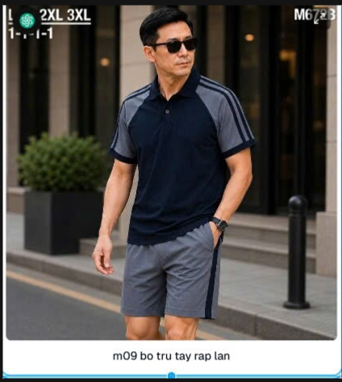

Tổng ký chuẩn (kg)

520 kg

Tổng ký thực tế (kg)

kg

Tổng màu & Tỉ lệ size

4 màu | 1-1-1-1

SL 1 màu:

100 cái (130 kg)

2. CHIA THEO MÀU (THEO TỶ LỆ SIZE & KG CHUẨN)

*Ghi chú: Đổi tên màu ở dòng tiêu đề để bảng đồng bộ xuống Mục 3; nhập tỉ lệ từng size (cột Tỉ lệ) và số kg cân thực tế từng màu.*

STT

SIZE / CHỈ TIÊU

TỈ LỆ

TRẮNG

BEGI

XANH ĐÁ

XÁM ĐẬM

TỔNG

GHI CHÚ SIZE

1

Size L

1

25

25

25

25

100

2

Size XL

1

25

25

25

25

100

3

Size XXL

1

25

25

25

25

100

4

Size 3XL

1

25

25

25

25

100

TỔNG SỐ LƯỢNG (CÁI)

4

100

100

100

100

400

Số kg chuẩn (kg)

Chuẩn

130

130

130

130

520

Theo định mức

Số kg thực tế (kg)

Cân TT

3. THEO DÕI CÁC KHÂU & SẢN LƯỢNG (KIỂM ĐẾM THỰC TẾ TỪNG MÀU)

STT

KHÂU / CÔNG ĐOẠN

TRẮNG

BEGI

XANH ĐÁ

XÁM ĐẬM

TỔNG (CÁI)

KÝ TÊN

1

Giao hàng

2

Khuy nút

3

Lỗi (Khuy nút)

4

Ủi

5

Lỗi (Ủi)

6

Đóng gói

7

Lỗi (Đóng gói)

8

Nhập kho

Chênh lệch từng màu (Kho - Giao)

Khâu ủi + Giao hàng xác nhận: ☐ Đủ theo kg & số lượng ☐ Thiếu theo kg / số lượng

Ký xác nhận gia công:

4. XÁC NHẬN & HÀNG SỬA

Tổng số lượng hàng lỗi:

cái

Loại lỗi chính:

Vải, chỉ, size, màu...

Số lượng sửa (cái):

cái

Trạng thái sửa:

☐ Đã sửa ☐ Chưa sửa

* Ghi chú thêm:

Đơn vị gia công: May áo: Xưởng may trụ anh Thông | May quần: Xưởng may quần chị Dung

5. KẾT LUẬN & ĐỐI CHIẾU THIẾU HỤT (NHẬP KHO - GIAO HÀNG)

Tổng nhập kho thành phẩm:

cái

Chênh lệch (Kho - Giao):

cái

☐ Đủ ☐ Thiếu

*Công thức đối soát: Chênh lệch = Tổng nhập kho - Giao hàng | Lệch chưa rõ = (Giao hàng - Nhập kho) - (Tổng lỗi - SL đã sửa)*

NGƯỜI LẬP / GIAO HÀNG

TỔ KIỂM HÀNG (KHUY NÚT - ỦI - ĐÓNG GÓI)

THỦ KHO / QUẢN LÝ

(Ký, ghi rõ họ tên)

(Ký, ghi rõ họ tên)

(Ký, ghi rõ họ tên)

PHIẾU CẮT & THEO DÕI GIAO NHẬN - POLOMIMIN

NGÀY LẬP PHIẾU

07 / 11 / 2026

MÃ PHIẾU CẮT

GC-20260319-001

Trạng thái: CHỜ KIỂM TRA

CÔNG TY TNHH DỆT MAY GIÀU SANG | MST: 0318507560 | Hotline: 0774480916 | 12/39 Xuân Thới Thượng 58C, Hóc Môn, TP.HCM

1. THÔNG TIN CHUNG & CHỈ TIÊU KIỂM ĐẾM

HÌNH ẢNH SẢN PHẨM

SL phiếu:

400 cái

[figure not shown]

Tổng ký chuẩn (kg)

520 kg

Tổng ký thực tế (kg)

kg

Tổng màu & Tỉ lệ size

4 màu | 1-1-1-1

SL 1 màu:

100 cái (130 kg)

2. CHIA THEO MÀU (THEO TỶ LỆ SIZE & KG CHUẨN)

*Ghi chú: Đổi tên màu ở dòng tiêu đề để bảng đồng bộ xuống Mục 3; nhập tỉ lệ từng size (cột Tỉ lệ) và số kg cân thực tế từng màu.*

STT

SIZE / CHỈ TIÊU

TỈ LỆ

ĐEN CM

NÂU

XANH ĐEN CM

XÁM ĐẬM

TỔNG

GHI CHÚ SIZE

1

Size L

1

25

25

25

25

100

2

Size XL

1

25

25

25

25

100

3

Size XXL

1

25

25

25

25

100

4

Size 3XL

1

25

25

25

25

100

TỔNG SỐ LƯỢNG (CÁI)

4

100

100

100

100

400

Số kg chuẩn (kg)

Chuẩn

130

130

130

130

520

Theo định mức

Số kg thực tế (kg)

Cân TT

3. THEO DÕI CÁC KHÂU & SẢN LƯỢNG (KIỂM ĐẾM THỰC TẾ TỪNG MÀU)

STT

KHÂU / CÔNG ĐOẠN

ĐEN CM

NÂU

XANH ĐEN CM

XÁM ĐẬM

TỔNG (CÁI)

KÝ TÊN

1

Giao hàng

2

Khuy nút

3

Lỗi (Khuy nút)

4

Ủi

5

Lỗi (Ủi)

6

Đóng gói

7

Lỗi (Đóng gói)

8

Nhập kho

Chênh lệch từng màu (Kho - Giao)

Khâu ủi + Giao hàng xác nhận: ☐ Đủ theo kg & số lượng ☐ Thiếu theo kg / số lượng

Ký xác nhận gia công:

4. XÁC NHẬN & HÀNG SỬA

Tổng số lượng hàng lỗi:

cái

Loại lỗi chính:

Vải, chỉ, size, màu...

Số lượng sửa (cái):

cái

Trạng thái sửa:

☐ Đã sửa ☐ Chưa sửa

* Ghi chú thêm:

Đơn vị gia công: In/Thêu: Xưởng thêu chị Hạnh | May áo: Xưởng may trụ anh Thông | May quần: Xưởng may quần chị Dung

5. KẾT LUẬN & ĐỐI CHIẾU THIẾU HỤT (NHẬP KHO - GIAO HÀNG)

Tổng nhập kho thành phẩm:

cái

Chênh lệch (Kho - Giao):

cái

☐ Đủ ☐ Thiếu

*Công thức đối soát: Chênh lệch = Tổng nhập kho - Giao hàng | Lệch chưa rõ = (Giao hàng - Nhập kho) - (Tổng lỗi - SL đã sửa)*

NGƯỜI LẬP / GIAO HÀNG

TỔ KIỂM HÀNG (KHUY NÚT - ỦI - ĐÓNG GÓI)

THỦ KHO / QUẢN LÝ

(Ký, ghi rõ họ tên)

(Ký, ghi rõ họ tên)

(Ký, ghi rõ họ tên)

PHIẾU CẮT & THEO DÕI GIAO NHẬN - POLOMIMIN

NGÀY LẬP PHIẾU

07 / 11 / 2026

MÃ PHIẾU CẮT

GC-20260319-001

Trạng thái: CHỜ KIỂM TRA

CÔNG TY TNHH DỆT MAY GIÀU SANG | MST: 0318507560 | Hotline: 0774480916 | 12/39 Xuân Thới Thượng 58C, Hóc Môn, TP.HCM

1. THÔNG TIN CHUNG & CHỈ TIÊU KIỂM ĐẾM

HÌNH ẢNH SẢN PHẨM

Mã hàng / Tên sản phẩm

M11 - BỘ TRỤ PHOI ĐÔ

SL phiếu:

400 cái

[figure not shown]

Tổng ký chuẩn (kg)

520 kg

Tổng ký thực tế (kg)

kg

Tổng màu & Tỉ lệ size

4 màu | 1-1-1-1

SL 1 màu:

100 cái (130 kg)

2. CHIA THEO MÀU (THEO TỶ LỆ SIZE & KG CHUẨN)

*Ghi chú: Đổi tên màu ở dòng tiêu đề để bảng đồng bộ xuống Mục 3; nhập tỉ lệ từng size (cột Tỉ lệ) và số kg cân thực tế từng màu.*

STT

SIZE / CHỈ TIÊU

TỈ LỆ

TRẮNG

BEGI

XANH ĐÁ

XÁM ĐẬM

TỔNG

GHI CHÚ SIZE

1

Size L

1

25

25

25

25

100

2

Size XL

1

25

25

25

25

100

3

Size XXL

1

25

25

25

25

100

4

Size 3XL

1

25

25

25

25

100

TỔNG SỐ LƯỢNG (CÁI)

4

100

100

100

100

400

Số kg chuẩn (kg)

Chuẩn

130

130

130

130

520

Theo định mức

Số kg thực tế (kg)

Cân TT

3. THEO DÕI CÁC KHÂU & SẢN LƯỢNG (KIỂM ĐẾM THỰC TẾ TỪNG MÀU)

STT

KHÂU / CÔNG ĐOẠN

TRẮNG

BEGI

XANH ĐÁ

XÁM ĐẬM

TỔNG (CÁI)

KÝ TÊN

1

Giao hàng

2

Khuy nút

3

Lỗi (Khuy nút)

4

Ủi

5

Lỗi (Ủi)

6

Đóng gói

7

Lỗi (Đóng gói)

8

Nhập kho

Chênh lệch từng màu (Kho - Giao)

Khâu ủi + Giao hàng xác nhận: ☐ Đủ theo kg & số lượng ☐ Thiếu theo kg / số lượng

Ký xác nhận gia công:

4. XÁC NHẬN & HÀNG SỬA

Tổng số lượng hàng lỗi:

cái

Loại lỗi chính:

Vải, chỉ, size, màu...

Số lượng sửa (cái):

cái

Trạng thái sửa:

☐ Đã sửa ☐ Chưa sửa

* Ghi chú thêm:

Đơn vị gia công: May áo: Xưởng may trụ cô Cúc | May quần: Xưởng may quần anh Thơ

5. KẾT LUẬN & ĐỐI CHIẾU THIẾU HỤT (NHẬP KHO - GIAO HÀNG)

Tổng nhập kho thành phẩm:

cái

Chênh lệch (Kho - Giao):

cái

☐ Đủ ☐ Thiếu

*Công thức đối soát: Chênh lệch = Tổng nhập kho - Giao hàng | Lệch chưa rõ = (Giao hàng - Nhập kho) - (Tổng lỗi - SL đã sửa)*

NGƯỜI LẬP / GIAO HÀNG

TỔ KIỂM HÀNG (KHUY NÚT - ỦI - ĐÓNG GÓI)

THỦ KHO / QUẢN LÝ

(Ký, ghi rõ họ tên)

(Ký, ghi rõ họ tên)

(Ký, ghi rõ họ tên)

PHIẾU CẮT & THEO DÕI GIAO NHẬN - POLOMIMIN

NGÀY LẬP PHIẾU

07 / 11 / 2026

MÃ PHIẾU CẮT

GC-20260319-001

Trạng thái: CHỜ KIỂM TRA

CÔNG TY TNHH DỆT MAY GIÀU SANG | MST: 0318507560 | Hotline: 0774480916 | 12/39 Xuân Thới Thượng 58C, Hóc Môn, TP.HCM

1. THÔNG TIN CHUNG & CHỈ TIÊU KIỂM ĐẾM

HÌNH ẢNH SẢN PHẨM

Mã hàng / Tên sản phẩm

M12 - BỘ TRỤ PHOI TAY

SL phiếu:

400 cái

[figure not shown]

Tổng ký chuẩn (kg)

520 kg

Tổng ký thực tế (kg)

kg

Tổng màu & Tỉ lệ size

4 màu | 1-1-1-1

SL 1 màu:

100 cái (130 kg)

2. CHIA THEO MÀU (THEO TỶ LỆ SIZE & KG CHUẨN)

*Ghi chú: Đổi tên màu ở dòng tiêu đề để bảng đồng bộ xuống Mục 3; nhập tỉ lệ từng size (cột Tỉ lệ) và số kg cân thực tế từng màu.*

STT

SIZE / CHỈ TIÊU

TỈ LỆ

TRẮNG

ĐEN CM

CỔ VỊT

XÁM NHẠT

TỔNG

GHI CHÚ SIZE

1

Size L

1

25

25

25

25

100

2

Size XL

1

25

25

25

25

100

3

Size XXL

1

25

25

25

25

100

4

Size 3XL

1

25

25

25

25

100

TỔNG SỐ LƯỢNG (CÁI)

4

100

100

100

100

400

Số kg chuẩn (kg)

Chuẩn

130

130

130

130

520

Theo định mức

Số kg thực tế (kg)

Cân TT

3. THEO DÕI CÁC KHÂU & SẢN LƯỢNG (KIỂM ĐẾM THỰC TẾ TỪNG MÀU)

STT

KHÂU / CÔNG ĐOẠN

TRẮNG

ĐEN CM

CỔ VỊT

XÁM NHẠT

TỔNG (CÁI)

KÝ TÊN

1

Giao hàng

2

Khuy nút

3

Lỗi (Khuy nút)

4

Ủi

5

Lỗi (Ủi)

6

Đóng gói

7

Lỗi (Đóng gói)

8

Nhập kho

Chênh lệch từng màu (Kho - Giao)

Khâu ủi + Giao hàng xác nhận: ☐ Đủ theo kg & số lượng ☐ Thiếu theo kg / số lượng

Ký xác nhận gia công:

4. XÁC NHẬN & HÀNG SỬA

Tổng số lượng hàng lỗi:

cái

Loại lỗi chính:

Vải, chỉ, size, màu...

Số lượng sửa (cái):

cái

Trạng thái sửa:

☐ Đã sửa ☐ Chưa sửa

* Ghi chú thêm:

Đơn vị gia công: In/Thêu: Xưởng thêu anh Vui | May áo: Xưởng may trụ cô Cúc | May quần: Xưởng may quần chị Hương

5. KẾT LUẬN & ĐỐI CHIẾU THIẾU HỤT (NHẬP KHO - GIAO HÀNG)

Tổng nhập kho thành phẩm:

cái

Chênh lệch (Kho - Giao):

cái

☐ Đủ ☐ Thiếu

*Công thức đối soát: Chênh lệch = Tổng nhập kho - Giao hàng | Lệch chưa rõ = (Giao hàng - Nhập kho) - (Tổng lỗi - SL đã sửa)*

NGƯỜI LẬP / GIAO HÀNG

TỔ KIỂM HÀNG (KHUY NÚT - ỦI - ĐÓNG GÓI)

THỦ KHO / QUẢN LÝ

(Ký, ghi rõ họ tên)

(Ký, ghi rõ họ tên)

(Ký, ghi rõ họ tên)

PHIẾU CẮT & THEO DÕI GIAO NHẬN - POLOMIMIN

NGÀY LẬP PHIẾU

07 / 11 / 2026

MÃ PHIẾU CẮT

GC-20260319-001

Trạng thái: CHỜ KIỂM TRA

CÔNG TY TNHH DỆT MAY GIÀU SANG | MST: 0318507560 | Hotline: 0774480916 | 12/39 Xuân Thới Thượng 58C, Hóc Môn, TP.HCM

1. THÔNG TIN CHUNG & CHỈ TIÊU KIỂM ĐẾM

HÌNH ẢNH SẢN PHẨM

Mã hàng / Tên sản phẩm

M13 - BỘ TRỤ PHỐI ĐÔ

SL phiếu:

320 cái

[figure not shown]

Tổng ký chuẩn (kg)

520 kg

Tổng ký thực tế (kg)

kg

Tổng màu & Tỉ lệ size

4 màu | 1-1-1-1

SL 1 màu:

80 cái (130 kg)

2. CHIA THEO MÀU (THEO TỶ LỆ SIZE & KG CHUẨN)

*Ghi chú: Đổi tên màu ở dòng tiêu đề để bảng đồng bộ xuống Mục 3; nhập tỉ lệ từng size (cột Tỉ lệ) và số kg cân thực tế từng màu.*

STT

SIZE / CHỈ TIÊU

TỈ LỆ

TRẮNG

ĐEN CM

RÊU

CỎ ÚA

TỔNG

GHI CHÚ SIZE

1

Size L

1

20

20

20

20

80

2

Size XL

1

20

20

20

20

80

3

Size XXL

1

20

20

20

20

80

4

Size 3XL

1

20

20

20

20

80

TỔNG SỐ LƯỢNG (CÁI)

4

80

80

80

80

320

Số kg chuẩn (kg)

Chuẩn

130

130

130

130

520

Theo định mức

Số kg thực tế (kg)

Cân TT

3. THEO DÕI CÁC KHÂU & SẢN LƯỢNG (KIỂM ĐẾM THỰC TẾ TỪNG MÀU)

STT

KHÂU / CÔNG ĐOẠN

TRẮNG

ĐEN CM

RÊU

CỎ ÚA

TỔNG (CÁI)

KÝ TÊN

1

Giao hàng

2

Khuy nút

3

Lỗi (Khuy nút)

4

Ủi

5

Lỗi (Ủi)

6

Đóng gói

7

Lỗi (Đóng gói)

8

Nhập kho

Chênh lệch từng màu (Kho - Giao)

Khâu ủi + Giao hàng xác nhận: ☐ Đủ theo kg & số lượng ☐ Thiếu theo kg / số lượng

Ký xác nhận gia công:

4. XÁC NHẬN & HÀNG SỬA

Tổng số lượng hàng lỗi:

cái

Loại lỗi chính:

Vải, chỉ, size, màu...

Số lượng sửa (cái):

cái

Trạng thái sửa:

☐ Đã sửa ☐ Chưa sửa

* Ghi chú thêm:

Đơn vị gia công: May áo: Xưởng may trụ chị Liễu | May quần: Xưởng may quần anh Thơ

5. KẾT LUẬN & ĐỐI CHIẾU THIẾU HỤT (NHẬP KHO - GIAO HÀNG)

Tổng nhập kho thành phẩm:

cái

Chênh lệch (Kho - Giao):

cái

☐ Đủ ☐ Thiếu

*Công thức đối soát: Chênh lệch = Tổng nhập kho - Giao hàng | Lệch chưa rõ = (Giao hàng - Nhập kho) - (Tổng lỗi - SL đã sửa)*

NGƯỜI LẬP / GIAO HÀNG

TỔ KIỂM HÀNG (KHUY NÚT - ỦI - ĐÓNG GÓI)

THỦ KHO / QUẢN LÝ

(Ký, ghi rõ họ tên)

(Ký, ghi rõ họ tên)

(Ký, ghi rõ họ tên)

PHIẾU CẮT & THEO DÕI GIAO NHẬN - POLOMIMIN

NGÀY LẬP PHIẾU

07 / 11 / 2026

MÃ PHIẾU CẮT

GC-20260319-001

Trạng thái: CHỜ KIỂM TRA

CÔNG TY TNHH DỆT MAY GIÀU SANG | MST: 0318507560 | Hotline: 0774480916 | 12/39 Xuân Thới Thượng 58C, Hóc Môn, TP.HCM

1. THÔNG TIN CHUNG & CHỈ TIÊU KIỂM ĐẾM

HÌNH ẢNH SẢN PHẨM

Mã hàng / Tên sản phẩm

M14 - BỘ TRỤ PHỐI VAI CHẠY LÉ

SL phiếu:

400 cái

[figure not shown]

Tổng ký chuẩn (kg)

520 kg

Tổng ký thực tế (kg)

kg

Tổng màu & Tỉ lệ size

4 màu | 1-1-1-1

SL 1 màu:

100 cái (130 kg)

2. CHIA THEO MÀU (THEO TỶ LỆ SIZE & KG CHUẨN)

*Ghi chú: Đổi tên màu ở dòng tiêu đề để bảng đồng bộ xuống Mục 3; nhập tỉ lệ từng size (cột Tỉ lệ) và số kg cân thực tế từng màu.*

STT

SIZE / CHỈ TIÊU

TỈ LỆ

TRẮNG

ĐEN CM

XANH NHỚT

DA

TỔNG

GHI CHÚ SIZE

1

Size L

1

25

25

25

25

100

2

Size XL

1

25

25

25

25

100

3

Size XXL

1

25

25

25

25

100

4

Size 3XL

1

25

25

25

25

100

TỔNG SỐ LƯỢNG (CÁI)

4

100

100

100

100

400

Số kg chuẩn (kg)

Chuẩn

130

130

130

130

520

Theo định mức

Số kg thực tế (kg)

Cân TT

3. THEO DÕI CÁC KHÂU & SẢN LƯỢNG (KIỂM ĐẾM THỰC TẾ TỪNG MÀU)

STT

KHÂU / CÔNG ĐOẠN

TRẮNG

ĐEN CM

XANH NHỚT

DA

TỔNG (CÁI)

KÝ TÊN

1

Giao hàng

2

Khuy nút

3

Lỗi (Khuy nút)

4

Ủi

5

Lỗi (Ủi)

6

Đóng gói

7

Lỗi (Đóng gói)

8

Nhập kho

Chênh lệch từng màu (Kho - Giao)

Khâu ủi + Giao hàng xác nhận: ☐ Đủ theo kg & số lượng ☐ Thiếu theo kg / số lượng

Ký xác nhận gia công:

4. XÁC NHẬN & HÀNG SỬA

Tổng số lượng hàng lỗi:

cái

Loại lỗi chính:

Vải, chỉ, size, màu...

Số lượng sửa (cái):

cái

Trạng thái sửa:

☐ Đã sửa ☐ Chưa sửa

* Ghi chú thêm:

Đơn vị gia công: In/Thêu: Xưởng thêu anh Vui | May áo: Xưởng may trụ anh Thông | May quần: Xưởng may quần chị Dung

5. KẾT LUẬN & ĐỐI CHIẾU THIẾU HỤT (NHẬP KHO - GIAO HÀNG)

Tổng nhập kho thành phẩm:

cái

Chênh lệch (Kho - Giao):

cái

☐ Đủ ☐ Thiếu

*Công thức đối soát: Chênh lệch = Tổng nhập kho - Giao hàng | Lệch chưa rõ = (Giao hàng - Nhập kho) - (Tổng lỗi - SL đã sửa)*

NGƯỜI LẬP / GIAO HÀNG

TỔ KIỂM HÀNG (KHUY NÚT - ỦI - ĐÓNG GÓI)

THỦ KHO / QUẢN LÝ

(Ký, ghi rõ họ tên)

(Ký, ghi rõ họ tên)

(Ký, ghi rõ họ tên)

PHIẾU CẮT & THEO DÕI GIAO NHẬN - POLOMIMIN

NGÀY LẬP PHIẾU

07 / 11 / 2026

MÃ PHIẾU CẮT

GC-20260319-001

Trạng thái: CHỜ KIỂM TRA

CÔNG TY TNHH DỆT MAY GIÀU SANG | MST: 0318507560 | Hotline: 0774480916 | 12/39 Xuân Thới Thượng 58C, Hóc Môn, TP.HCM

1. THÔNG TIN CHUNG & CHỈ TIÊU KIỂM ĐẾM

HÌNH ẢNH SẢN PHẨM

Mã hàng / Tên sản phẩm

M15 - BỘ TRÒN PHỐI VAI-LÉ

SL phiếu:

400 cái

[figure not shown]

Tổng ký chuẩn (kg)

520 kg

Tổng ký thực tế (kg)

kg

Tổng màu & Tỉ lệ size

4 màu | 1-1-1-1

SL 1 màu:

100 cái (130 kg)

2. CHIA THEO MÀU (THEO TỶ LỆ SIZE & KG CHUẨN)

*Ghi chú: Đổi tên màu ở dòng tiêu đề để bảng đồng bộ xuống Mục 3; nhập tỉ lệ từng size (cột Tỉ lệ) và số kg cân thực tế từng màu.*

STT

SIZE / CHỈ TIÊU

TỈ LỆ

TRẮNG

ĐEN CM

XANH NHỚT

DA

TỔNG

GHI CHÚ SIZE

1

Size L

1

25

25

25

25

100

2

Size XL

1

25

25

25

25

100

3

Size XXL

1

25

25

25

25

100

4

Size 3XL

1

25

25

25

25

100

TỔNG SỐ LƯỢNG (CÁI)

4

100

100

100

100

400

Số kg chuẩn (kg)

Chuẩn

130

130

130

130

520

Theo định mức

Số kg thực tế (kg)

Cân TT

3. THEO DÕI CÁC KHÂU & SẢN LƯỢNG (KIỂM ĐẾM THỰC TẾ TỪNG MÀU)

STT

KHÂU / CÔNG ĐOẠN

TRẮNG

ĐEN CM

XANH NHỚT

DA

TỔNG (CÁI)

KÝ TÊN

1

Giao hàng

2

Khuy nút

3

Lỗi (Khuy nút)

4

Ủi

5

Lỗi (Ủi)

6

Đóng gói

7

Lỗi (Đóng gói)

8

Nhập kho

Chênh lệch từng màu (Kho - Giao)

Khâu ủi + Giao hàng xác nhận: ☐ Đủ theo kg & số lượng ☐ Thiếu theo kg / số lượng

Ký xác nhận gia công:

4. XÁC NHẬN & HÀNG SỬA

Tổng số lượng hàng lỗi:

cái

Loại lỗi chính:

Vải, chỉ, size, màu...

Số lượng sửa (cái):

cái

Trạng thái sửa:

☐ Đã sửa ☐ Chưa sửa

* Ghi chú thêm:

Đơn vị gia công: In/Thêu: Xưởng thêu anh Vui | May áo: Xưởng may tròn anh Trai | May quần: Xưởng may quần chị Dung

5. KẾT LUẬN & ĐỐI CHIẾU THIẾU HỤT (NHẬP KHO - GIAO HÀNG)

Tổng nhập kho thành phẩm:

cái

Chênh lệch (Kho - Giao):

cái

☐ Đủ ☐ Thiếu

*Công thức đối soát: Chênh lệch = Tổng nhập kho - Giao hàng | Lệch chưa rõ = (Giao hàng - Nhập kho) - (Tổng lỗi - SL đã sửa)*

NGƯỜI LẬP / GIAO HÀNG

TỔ KIỂM HÀNG (KHUY NÚT - ỦI - ĐÓNG GÓI)

THỦ KHO / QUẢN LÝ

(Ký, ghi rõ họ tên)

(Ký, ghi rõ họ tên)

(Ký, ghi rõ họ tên)

PHIẾU CẮT & THEO DÕI GIAO NHẬN - POLOMIMIN

NGÀY LẬP PHIẾU

07 / 11 / 2026

MÃ PHIẾU CẮT

GC-20260319-001

Trạng thái: CHỜ KIỂM TRA

CÔNG TY TNHH DỆT MAY GIÀU SANG | MST: 0318507560 | Hotline: 0774480916 | 12/39 Xuân Thới Thượng 58C, Hóc Môn, TP.HCM

1. THÔNG TIN CHUNG & CHỈ TIÊU KIỂM ĐẾM

HÌNH ẢNH SẢN PHẨM

Mã hàng / Tên sản phẩm

M16 - BỘ TRỤ TRƠN

SL phiếu:

320 cái

[figure not shown]

Tổng ký chuẩn (kg)

520 kg

Tổng ký thực tế (kg)

kg

Tổng màu & Tỉ lệ size

4 màu | 1-1-1-1

SL 1 màu:

80 cái (130 kg)

2. CHIA THEO MÀU (THEO TỶ LỆ SIZE & KG CHUẨN)

*Ghi chú: Đổi tên màu ở dòng tiêu đề để bảng đồng bộ xuống Mục 3; nhập tỉ lệ từng size (cột Tỉ lệ) và số kg cân thực tế từng màu.*

STT

SIZE / CHỈ TIÊU

TỈ LỆ

TRẮNG

ĐEN CM

RÊU

CỎ ÚA

TỔNG

GHI CHÚ SIZE

1

Size L

1

20

20

20

20

80

2

Size XL

1

20

20

20

20

80

3

Size XXL

1

20

20

20

20

80

4

Size 3XL

1

20

20

20

20

80

TỔNG SỐ LƯỢNG (CÁI)

4

80

80

80

80

320

Số kg chuẩn (kg)

Chuẩn

130

130

130

130

520

Theo định mức

Số kg thực tế (kg)

Cân TT

3. THEO DÕI CÁC KHÂU & SẢN LƯỢNG (KIỂM ĐẾM THỰC TẾ TỪNG MÀU)

STT

KHÂU / CÔNG ĐOẠN

TRẮNG

ĐEN CM

RÊU

CỎ ÚA

TỔNG (CÁI)

KÝ TÊN

1

Giao hàng

2

Khuy nút

3

Lỗi (Khuy nút)

4

Ủi

5

Lỗi (Ủi)

6

Đóng gói

7

Lỗi (Đóng gói)

8

Nhập kho

Chênh lệch từng màu (Kho - Giao)

Khâu ủi + Giao hàng xác nhận: ☐ Đủ theo kg & số lượng ☐ Thiếu theo kg / số lượng

Ký xác nhận gia công:

4. XÁC NHẬN & HÀNG SỬA

Tổng số lượng hàng lỗi:

cái

Loại lỗi chính:

Vải, chỉ, size, màu...

Số lượng sửa (cái):

cái

Trạng thái sửa:

☐ Đã sửa ☐ Chưa sửa

* Ghi chú thêm:

Đơn vị gia công: In/Thêu: Xưởng thêu chị Hạnh | May áo: Xưởng may trụ anh Thông | May quần: Xưởng may quần anh Thơ

5. KẾT LUẬN & ĐỐI CHIẾU THIẾU HỤT (NHẬP KHO - GIAO HÀNG)

Tổng nhập kho thành phẩm:

cái

Chênh lệch (Kho - Giao):

cái

☐ Đủ ☐ Thiếu

*Công thức đối soát: Chênh lệch = Tổng nhập kho - Giao hàng | Lệch chưa rõ = (Giao hàng - Nhập kho) - (Tổng lỗi - SL đã sửa)*

NGƯỜI LẬP / GIAO HÀNG

TỔ KIỂM HÀNG (KHUY NÚT - ỦI - ĐÓNG GÓI)

THỦ KHO / QUẢN LÝ

(Ký, ghi rõ họ tên)

(Ký, ghi rõ họ tên)

(Ký, ghi rõ họ tên)

PHIẾU CẮT & THEO DÕI GIAO NHẬN - POLOMIMIN

NGÀY LẬP PHIẾU

12 / 11 / 2026

MÃ PHIẾU CẮT

GC-20260319-001

Trạng thái: CHỜ KIỂM TRA

CÔNG TY TNHH DỆT MAY GIÀU SANG | MST: 0318507560 | Hotline: 0774480916 | 12/39 Xuân Thới Thượng 58C, Hóc Môn, TP.HCM

1. THÔNG TIN CHUNG & CHỈ TIÊU KIỂM ĐẾM

HÌNH ẢNH SẢN PHẨM

Mã hàng / Tên sản phẩm

BÀN 196-PBJ-288 - BỘ TRỤ PHỐI NGANG NGỰC 2 THANH

SL phiếu:

400 cái

[figure not shown]

Tổng ký chuẩn (kg)

650 kg

Tổng ký thực tế (kg)

kg

Tổng màu & Tỉ lệ size

5 màu | 1-1-1-1

SL 1 màu:

80 cái (130 kg)

2. CHIA THEO MÀU (THEO TỶ LỆ SIZE & KG CHUẨN)

*Ghi chú: Đổi tên màu ở dòng tiêu đề để bảng đồng bộ xuống Mục 3; nhập tỉ lệ từng size (cột Tỉ lệ) và số kg cân thực tế từng màu.*

STT

SIZE / CHỈ TIÊU

TỈ LỆ

TRẮNG

ĐEN

XÁM NHẠT

NÂU 11

BEGI

TỔNG

GHI CHÚ SIZE

1

Size L

1

20

20

20

20

20

100

2

Size XL

1

20

20

20

20

20

100

3

Size XXL

1

20

20

20

20

20

100

4

Size 3XL

1

20

20

20

20

20

100

TỔNG SỐ LƯỢNG (CÁI)

4

80

80

80

80

80

400

Số kg chuẩn (kg)

Chuẩn

130

130

130

130

130

650

Theo định mức

Số kg thực tế (kg)

Cân TT

3. THEO DÕI CÁC KHÂU & SẢN LƯỢNG (KIỂM ĐẾM THỰC TẾ TỪNG MÀU)

STT

KHÂU / CÔNG ĐOẠN

TRẮNG

ĐEN

XÁM NHẠT

NÂU 11

BEGI

TỔNG (CÁI)

KÝ TÊN

1

Giao hàng

2

Khuy nút

3

Lỗi (Khuy nút)

4

Ủi

5

Lỗi (Ủi)

6

Đóng gói

7

Lỗi (Đóng gói)

8

Nhập kho

Chênh lệch từng màu (Kho - Giao)

Khâu ủi + Giao hàng xác nhận: ☐ Đủ theo kg & số lượng ☐ Thiếu theo kg / số lượng

Ký xác nhận gia công:

4. XÁC NHẬN & HÀNG SỬA

Tổng số lượng hàng lỗi:

cái

Loại lỗi chính:

Vải, chỉ, size, màu...

Số lượng sửa (cái):

cái

Trạng thái sửa:

☐ Đã sửa ☐ Chưa sửa

* Ghi chú thêm:

Đơn vị gia công: May áo: Xưởng may trụ anh Thông | May quần: Xưởng may quần chị Dung

5. KẾT LUẬN & ĐỐI CHIẾU THIẾU HỤT (NHẬP KHO - GIAO HÀNG)

Tổng nhập kho thành phẩm:

cái

Chênh lệch (Kho - Giao):

cái

☐ Đủ ☐ Thiếu

*Công thức đối soát: Chênh lệch = Tổng nhập kho - Giao hàng | Lệch chưa rõ = (Giao hàng - Nhập kho) - (Tổng lỗi - SL đã sửa)*

NGƯỜI LẬP / GIAO HÀNG

TỔ KIỂM HÀNG (KHUY NÚT - ỦI - ĐÓNG GÓI)

THỦ KHO / QUẢN LÝ

(Ký, ghi rõ họ tên)

(Ký, ghi rõ họ tên)

(Ký, ghi rõ họ tên)

PHIẾU CẮT & THEO DÕI GIAO NHẬN - POLOMIMIN

NGÀY LẬP PHIẾU

12 / 11 / 2026

MÃ PHIẾU CẮT

GC-20260319-001

Trạng thái: CHỜ KIỂM TRA

CÔNG TY TNHH DỆT MAY GIÀU SANG | MST: 0318507560 | Hotline: 0774480916 | 12/39 Xuân Thới Thượng 58C, Hóc Môn, TP.HCM

1. THÔNG TIN CHUNG & CHỈ TIÊU KIỂM ĐẾM

HÌNH ẢNH SẢN PHẨM

Mã hàng / Tên sản phẩm

BÀN 196-PBJ-332 - BỘ TRỤ TRƠN

SL phiếu:

400 cái

[figure not shown]

Tổng ký chuẩn (kg)

650 kg

Tổng ký thực tế (kg)

kg

Tổng màu & Tỉ lệ size

5 màu | 1-1-1-1

SL 1 màu:

80 cái (130 kg)

2. CHIA THEO MÀU (THEO TỶ LỆ SIZE & KG CHUẨN)

*Ghi chú: Đổi tên màu ở dòng tiêu đề để bảng đồng bộ xuống Mục 3; nhập tỉ lệ từng size (cột Tỉ lệ) và số kg cân thực tế từng màu.*

STT

SIZE / CHỈ TIÊU

TỈ LỆ

TRẮNG

ĐEN

XÁM NHẠT

NÂU 11

BEGI

TỔNG

GHI CHÚ SIZE

1

Size L

1

20

20

20

20

20

100

2

Size XL

1

20

20

20

20

20

100

3

Size XXL

1

20

20

20

20

20

100

4

Size 3XL

1

20

20

20

20

20

100

TỔNG SỐ LƯỢNG (CÁI)

4

80

80

80

80

80

400

Số kg chuẩn (kg)

Chuẩn

130

130

130

130

130

650

Theo định mức

Số kg thực tế (kg)

Cân TT

3. THEO DÕI CÁC KHÂU & SẢN LƯỢNG (KIỂM ĐẾM THỰC TẾ TỪNG MÀU)

STT

KHÂU / CÔNG ĐOẠN

TRẮNG

ĐEN

XÁM NHẠT

NÂU 11

BEGI

TỔNG (CÁI)

KÝ TÊN

1

Giao hàng

2

Khuy nút

3

Lỗi (Khuy nút)

4

Ủi

5

Lỗi (Ủi)

6

Đóng gói

7

Lỗi (Đóng gói)

8

Nhập kho

Chênh lệch từng màu (Kho - Giao)

Khâu ủi + Giao hàng xác nhận: ☐ Đủ theo kg & số lượng ☐ Thiếu theo kg / số lượng

Ký xác nhận gia công:

4. XÁC NHẬN & HÀNG SỬA

Tổng số lượng hàng lỗi:

cái

Loại lỗi chính:

Vải, chỉ, size, màu...

Số lượng sửa (cái):

cái

Trạng thái sửa:

☐ Đã sửa ☐ Chưa sửa

* Ghi chú thêm:

Đơn vị gia công: In/Thêu: Xưởng thêu chị Hạnh | May áo: Xưởng may anh Long | May quần: Xưởng may quần chị Dung

5. KẾT LUẬN & ĐỐI CHIẾU THIẾU HỤT (NHẬP KHO - GIAO HÀNG)

Tổng nhập kho thành phẩm:

cái

Chênh lệch (Kho - Giao):

cái

☐ Đủ ☐ Thiếu

*Công thức đối soát: Chênh lệch = Tổng nhập kho - Giao hàng | Lệch chưa rõ = (Giao hàng - Nhập kho) - (Tổng lỗi - SL đã sửa)*

NGƯỜI LẬP / GIAO HÀNG

TỔ KIỂM HÀNG (KHUY NÚT - ỦI - ĐÓNG GÓI)

THỦ KHO / QUẢN LÝ

(Ký, ghi rõ họ tên)

(Ký, ghi rõ họ tên)

(Ký, ghi rõ họ tên)